# Reviewer comments

Accompanying ‘Monocyte-chemoattractant protein-1 Levels in Human Atherosclerosis Associate with Plaque Vulnerability.’

[Sander W. van der Laan, PhD](https://swvanderlaan.github.io) | @swvanderlaan; Marios Georgakis, and many others.

2021-02-11

# Preparation

Clean the environment.

Set locations, and the working directory.

A package-installation function.

Load those packages.

```r
install.packages.auto("readr")
install.packages.auto("optparse")
install.packages.auto("tools")
install.packages.auto("dplyr")
install.packages.auto("tidyr")
install.packages.auto("naniar")

# To get 'data.table' with 'fwrite' to be able to directly write gzipped-files
# Ref: https://stackoverflow.com/questions/42788401/is-possible-to-use-fwrite-from-data-table-with-gzfile
# install.packages("data.table", repos = "https://Rdatatable.gitlab.io/data.table")
library(data.table)

install.packages.auto("tidyverse")
install.packages.auto("knitr")
install.packages.auto("DT")
install.packages.auto("MASS")
# install.packages.auto("Seurat") # latest version

# Install the devtools package from Hadley Wickham
install.packages.auto('devtools')

install.packages.auto("haven")
install.packages.auto("sjlabelled")
install.packages.auto("sjPlot")
install.packages.auto("labelled")
install.packages.auto("tableone")

install.packages.auto("ggpubr")
```

We will create a datestamp and define the Utrecht Science Park Colour Scheme.

# Background

This notebook contains additional analyses and figures of the project “Monocyte-chemoattractant protein-1 Levels in Human Atherosclerosis Associate with Plaque Vulnerability.” to accomodate the reviewer comments.

# Loading data

```r
load(paste0(PROJECT_loc, "/",Today,".",PROJECTNAME,".additional_figures.RData"))
# load(paste0(PROJECT_loc, "/20200714.",PROJECTNAME,".additional_figures.RData"))
```

# Comparison plaque and plasma levels

Here we draw a correlation between plasma and plaque MCP1 levels

```r
cat("Comparing descriptive statistics.\n")
```

```
Comparing descriptive statistics.
```

```r
cat("* plasma levels, OLINK, arbitrary units [au]\n")
```

```
* plasma levels, OLINK, arbitrary units [au]
```

```r
summary(AEDB.CEA$MCP1_plasma_olink)
```

```
   Min. 1st Qu.  Median    Mean 3rd Qu.    Max.    NA's
 0.6649  3.3219  3.5617  3.6081  3.8117 12.2641    1736
```

```r
cat("\n* plasma levels, OLINK, arbitrary units [au], inverse rank-normalized\n")
```

```
* plasma levels, OLINK, arbitrary units [au], inverse rank-normalized
```

```r
summary(AEDB.CEA$MCP1_plasma_olink_rankNorm)
```

```
   Min. 1st Qu.  Median    Mean 3rd Qu.    Max.    NA's
-5.0879 -0.4954 -0.0810 -0.0006  0.3512 14.9609    1736
```

```r
cat("\n* plaque levels, LUMINEX, [pg/mL]\n")
```

```
* plaque levels, LUMINEX, [pg/mL]
```

```r
summary(AEDB.CEA$MCP1_pg_ml_2015)
```

```
    Min.  1st Qu.   Median     Mean  3rd Qu.     Max.     NA's
    0.66   101.34   298.76   600.44   770.98 10181.08     1224
```

```r
cat("'n* plaque levels, LUMINEX, [pg/mL], inverse rank-normalized\n")
```

```
'n* plaque levels, LUMINEX, [pg/mL], inverse rank-normalized
```

```r
summary(AEDB.CEA$MCP1_pg_ml_2015_rank)
```

```
   Min. 1st Qu.  Median    Mean 3rd Qu.    Max.    NA's
-3.3412 -0.6738  0.0000  0.0000  0.6738  3.3412    1224
```

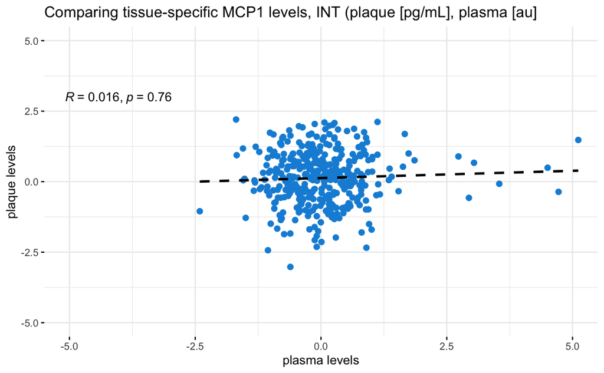

```r
ggpubr::ggscatter(AEDB.CEA,
                  x = "MCP1_plasma_olink_rankNorm",
                  y = "MCP1_pg_ml_2015_rank",
                  color = "#1290D9",
                  # fill = "Gender",
                  # palette = c("#1290D9", "#DB003F"),
                  add = "reg.line",
                  add.params =  list(color = "black", linetype = 2),
                  cor.coef = TRUE, cor.method = "spearman",
                  xlim = c(-5, 5), ylim = c(-5, 5),
                  xlab = "plasma levels",
                  ylab = "plaque levels",
                  title = "Comparing tissue-specific MCP1 levels, INT (plaque [pg/mL], plasma [au]",
                  ggtheme = theme_minimal())

ggsave(filename = paste0(QC_loc, "/",Today,".",PROJECTNAME,".Comparison.plasma_vs_plaque.pdf"),
         plot = last_plot())
ggsave(filename = paste0(QC_loc, "/",Today,".",PROJECTNAME,".Comparison.plasma_vs_plaque.png"),
         plot = last_plot())
```

The overlap between plasma and plaque samples.

```r
temp <- subset(AEDB.CEA, select = c("STUDY_NUMBER", "MCP1_pg_ml_2015_rank", "MCP1_plasma_olink_rankNorm"))

temp_new <- temp[complete.cases(temp), ]
dim(temp_new)
```

```
[1] 374   3
```

```r
# rm(temp, temp_new)
```

# Expression of MCP1 in single-cells from carotid plaques

In a separate notebook we provide the results from the scRNAseq analysis: `scRNAseq/scRNAseq.nb.html`.

# Correlation with monocyte counts

In the past we did measure monocyte counts in a *subset* of the Athero-Express. We first inspect what the overlap is with the plaque MCP1 measurements.

```r
library(openxlsx)
AEDB_mono <- openxlsx::read.xlsx(paste0(AEDB_loc, "/_AE_CircCells/AE_study_numbers_mono_FACS.xlsx"))

head(AEDB_mono)
```

|  | STUDY_NUMBER | MonocyteCount |
| --- | --- | --- |
| 1 | 1850 | yes |
| 2 | 2229 | yes |
| 3 | 2258 | yes |
| 4 | 2261 | yes |
| 5 | 2263 | yes |
| 6 | 2268 | yes |

```r
AEDB_monoMCP1 <- merge(AEDB_mono, temp, by.x = "STUDY_NUMBER", by.y = "STUDY_NUMBER", sort = FALSE, all.x = TRUE)

dim(AEDB_monoMCP1)
```

```
[1] 179   4
```

# Cytokines vs. MCP1 levels

We explore whether cytokines (only the ones associated with MCP1) also associate with plaque vulnerability, and even in a multivariable model include them together with MCP1. This way we only indirectly provide some clues about whether MCP1 is the primary driver of plaque vulnerability. A lack of association between cytokines and plaque vulnerability in these models, would imply that they are the result of MCP1 increase independently of the effects of MCP1 on plaque vulnerability. And thus, not all of them together represent the response to the stimuli.

## Model 1: Univariate cytokines/chemokines vs plaque vulnerability

In this model we correct for *Age*, *Gender*, and *year of surgery*.

Here we use the inverse-rank normalized data - visually this is more normally distributed.

Analysis of the plaque vulnerability indez as a function of plaque cytokine levels.

```r
# For quick debug inspection
# TRAITS.PROTEIN.RANK.extra = c("MCP1_pg_ml_2015_rank")
# proteins_of_interest_rank_mcp1
# proteins_of_interest_rank

GLM.results <- data.frame(matrix(NA, ncol = 16, nrow = 0))
for (protein in 1:length(proteins_of_interest_rank)) {
  PROTEIN = proteins_of_interest_rank[protein]
  cat(paste0("\nAnalysis of ",PROTEIN,".\n"))
  TRAIT = "Plaque_Vulnerability_Index"
    cat(paste0("\n- processing ",TRAIT,"\n\n"))
    currentDF <- as.data.frame(AEDB.CEA %>%
      dplyr::select(., PROTEIN, TRAIT, COVARIATES_M1, ORdate_epoch) %>%
      filter(complete.cases(.))) %>%
      filter_if(~is.numeric(.), all_vars(!is.infinite(.))) %>%
      droplevels(.)

    # fix numeric OR year
    currentDF$ORdate_year <- as.numeric(currentDF$ORdate_year)

    # for debug
    # print(DT::datatable(currentDF))
    # print(nrow(currentDF))
    # print(str(currentDF))
    # print(class(currentDF[,TRAIT]))
    # table(currentDF$ORdate_year)
    ### univariate
     # + Hypertension.composite + DiabetesStatus + SmokerCurrent +
     #            Med.Statin.LLD + Med.all.antiplatelet + GFR_MDRD + BMI +
     #            CAD_history + Stroke_history + Peripheral.interv + stenose
    fit <- polr(currentDF[,TRAIT] ~ currentDF[,PROTEIN] + Age + Gender + ORdate_year,
              data  =  currentDF,
              Hess = TRUE)
    print(summary(fit))

    ## store table
    (ctable <- coef(summary(fit)))

    ## calculate and store p values
    p <- pnorm(abs(ctable[, "t value"]), lower.tail = FALSE) * 2

    ## combined table
    print((ctable <- cbind(ctable, "p value" = p)))
  }
```

```
Analysis of IL2_rank.

- processing Plaque_Vulnerability_Index

Call:
polr(formula = currentDF[, TRAIT] ~ currentDF[, PROTEIN] + Age +
    Gender + ORdate_year, data = currentDF, Hess = TRUE)

Coefficients:
                        Value Std. Error  t value
currentDF[, PROTEIN] -0.32916  0.0873723   -3.767
Age                   0.02184  0.0115829    1.885
Gendermale            0.57675  0.1936336    2.979
ORdate_year          -0.05603  0.0004207 -133.187

Intercepts:
    Value       Std. Error  t value
0|1   -113.7466      0.0063 -18177.6249
1|2   -111.9010      0.2316   -483.2123
2|3   -110.5544      0.2496   -442.8768
3|4   -108.9745      0.2723   -400.2632
4|5   -107.4705      0.3265   -329.1683

Residual Deviance: 1344.03
AIC: 1362.03
                             Value   Std. Error       t value      p value
currentDF[, PROTEIN]   -0.32916196 0.0873723062     -3.767349 0.0001649904
Age                     0.02183948 0.0115829442      1.885486 0.0593643002
Gendermale              0.57674790 0.1936335985      2.978553 0.0028961313
ORdate_year            -0.05602849 0.0004206748   -133.187185 0.0000000000
0|1                  -113.74658505 0.0062575053 -18177.624918 0.0000000000
1|2                  -111.90096052 0.2315772049   -483.212329 0.0000000000
2|3                  -110.55435390 0.2496277701   -442.876824 0.0000000000
3|4                  -108.97449368 0.2722571204   -400.263154 0.0000000000
4|5                  -107.47049099 0.3264909819   -329.168329 0.0000000000

Analysis of IL4_rank.

- processing Plaque_Vulnerability_Index

```

[output cut: 988 more lines]

```
3|4   124.8962     0.2404   519.4868
4|5   126.5077     0.2897   436.6316

Residual Deviance: 1687.186
AIC: 1705.186
                            Value   Std. Error      t value      p value
currentDF[, PROTEIN] 6.484757e-01 0.0820682934 7.901659e+00 2.752154e-15
Age                  8.479966e-03 0.0099382878 8.532623e-01 3.935139e-01
Gendermale           7.756174e-01 0.1735439615 4.469285e+00 7.848157e-06
ORdate_year          6.107898e-02 0.0003675612 1.661736e+02 0.000000e+00
0|1                  1.200457e+02 0.0056121382 2.139036e+04 0.000000e+00
1|2                  1.218126e+02 0.1997143107 6.099341e+02 0.000000e+00
2|3                  1.232669e+02 0.2184145468 5.643715e+02 0.000000e+00
3|4                  1.248962e+02 0.2404221964 5.194868e+02 0.000000e+00
4|5                  1.265077e+02 0.2897354940 4.366316e+02 0.000000e+00
```

## Model 2: MCP1 and plus 1 cytokine/chemokine vs plaque vulnerability

In this model we correct for *Age*, *Gender*, and *year of surgery*, and MCP1 plus *one* cytokines.

```r
COVARIATES_M1.extra = c("MCP1_pg_ml_2015_rank")

GLM.results <- data.frame(matrix(NA, ncol = 16, nrow = 0))
for (protein in 1:length(proteins_of_interest_rank)) {
  PROTEIN = proteins_of_interest_rank[protein]
  cat(paste0("\nAnalysis of ",PROTEIN,".\n"))
  TRAIT = "Plaque_Vulnerability_Index"
    cat(paste0("\n- processing ",TRAIT,"\n\n"))
    currentDF <- as.data.frame(AEDB.CEA %>%
      dplyr::select(., PROTEIN, TRAIT, COVARIATES_M1, COVARIATES_M1.extra, ORdate_epoch) %>%
      filter(complete.cases(.))) %>%
      filter_if(~is.numeric(.), all_vars(!is.infinite(.))) %>%
      droplevels(.)

    # fix numeric OR year
    currentDF$ORdate_year <- as.numeric(currentDF$ORdate_year)

    # for debug
    # print(DT::datatable(currentDF))
    # print(nrow(currentDF))
    # print(str(currentDF))
    # print(class(currentDF[,TRAIT]))
    # table(currentDF$ORdate_year)
    ### univariate
     # + Hypertension.composite + DiabetesStatus + SmokerCurrent +
     #            Med.Statin.LLD + Med.all.antiplatelet + GFR_MDRD + BMI +
     #            CAD_history + Stroke_history + Peripheral.interv + stenose
    fit <- polr(currentDF[,TRAIT] ~ currentDF[,PROTEIN] + Age + Gender + ORdate_year + MCP1_pg_ml_2015_rank,
              data  =  currentDF,
              Hess = TRUE)
    print(summary(fit))

    ## store table
    (ctable <- coef(summary(fit)))

    ## calculate and store p values
    p <- pnorm(abs(ctable[, "t value"]), lower.tail = FALSE) * 2

    ## combined table
    print((ctable <- cbind(ctable, "p value" = p)))
  }
```

```
Analysis of IL2_rank.

- processing Plaque_Vulnerability_Index
```

```
Note: Using an external vector in selections is ambiguous.
ℹ Use `all_of(COVARIATES_M1.extra)` instead of `COVARIATES_M1.extra` to silence this message.
ℹ See <https://tidyselect.r-lib.org/reference/faq-external-vector.html>.
```

```
Call:
polr(formula = currentDF[, TRAIT] ~ currentDF[, PROTEIN] + Age +
    Gender + ORdate_year + MCP1_pg_ml_2015_rank, data = currentDF,
    Hess = TRUE)

Coefficients:
                        Value Std. Error  t value
currentDF[, PROTEIN] -0.32974  0.1030587  -3.1996
Age                   0.01903  0.0132719   1.4341
Gendermale            0.54975  0.2159818   2.5454
ORdate_year           0.05440  0.0004816 112.9447
MCP1_pg_ml_2015_rank  0.10519  0.1092569   0.9628

Intercepts:
    Value      Std. Error t value
0|1   107.2834     0.0067 15950.6207
1|2   108.9521     0.2538   429.2737
2|3   110.4266     0.2777   397.6390
3|4   112.0634     0.3046   367.9400
4|5   113.8847     0.3944   288.7431

Residual Deviance: 1025.003
AIC: 1045.003
                            Value   Std. Error       t value     p value
currentDF[, PROTEIN]  -0.32974202 0.1030587296    -3.1995545 0.001376401
Age                    0.01903303 0.0132718978     1.4340850 0.151548010
Gendermale             0.54975069 0.2159818295     2.5453562 0.010916632
ORdate_year            0.05439671 0.0004816225   112.9446934 0.000000000
MCP1_pg_ml_2015_rank   0.10518813 0.1092568682     0.9627599 0.335668016
0|1                  107.28344285 0.0067259729 15950.6207300 0.000000000
1|2                  108.95209797 0.2538056444   429.2737391 0.000000000
2|3                  110.42660726 0.2777056632   397.6390182 0.000000000
3|4                  112.06342418 0.3045698284   367.9400050 0.000000000
4|5                  113.88470364 0.3944152756   288.7431362 0.000000000

Analysis of IL4_rank.

- processing Plaque_Vulnerability_Index

Call:
```

[output cut: 1071 more lines]

```
4|5   362.8917     0.3534  1026.9172

Residual Deviance: 1263.85
AIC: 1283.85
                            Value   Std. Error      t value      p value
currentDF[, PROTEIN] 6.083872e-01 0.0946293679 6.429158e+00 1.283124e-10
Age                  7.136729e-03 0.0110795737 6.441339e-01 5.194886e-01
Gendermale           7.230328e-01 0.1949487777 3.708835e+00 2.082153e-04
ORdate_year          1.789788e-01 0.0004111135 4.353513e+02 0.000000e+00
MCP1_pg_ml_2015_rank 1.715432e-01 0.0940872457 1.823235e+00 6.826775e-02
0|1                  3.561042e+02 0.0056013020 6.357526e+04 0.000000e+00
1|2                  3.577792e+02 0.2254261169 1.587124e+03 0.000000e+00
2|3                  3.593022e+02 0.2481601842 1.447864e+03 0.000000e+00
3|4                  3.610271e+02 0.2753721465 1.311052e+03 0.000000e+00
4|5                  3.628917e+02 0.3533797095 1.026917e+03 0.000000e+00
```

## Model 3: MCP1 and all cytokines/chemokines vs plaque vulnerability

```r
COVARIATES_M1.extra = c("MCP1_pg_ml_2015_rank")

GLM.results <- data.frame(matrix(NA, ncol = 16, nrow = 0))
  TRAIT = "Plaque_Vulnerability_Index"

    currentDF <- as.data.frame(AEDB.CEA %>%
      dplyr::select(., proteins_of_interest_rank, TRAIT, COVARIATES_M1, COVARIATES_M1.extra, ORdate_epoch) %>%
      filter(complete.cases(.))) %>%
      filter_if(~is.numeric(.), all_vars(!is.infinite(.))) %>%
      droplevels(.)
```

```
Note: Using an external vector in selections is ambiguous.
ℹ Use `all_of(proteins_of_interest_rank)` instead of `proteins_of_interest_rank` to silence this message.
ℹ See <https://tidyselect.r-lib.org/reference/faq-external-vector.html>.
```

```r
    # fix numeric OR year
    currentDF$ORdate_year <- as.numeric(currentDF$ORdate_year)

    fit <- polr(currentDF[,TRAIT] ~ currentDF[,PROTEIN] + Age + Gender + ORdate_year + MCP1_pg_ml_2015_rank + IL2_rank + IL4_rank + IL5_rank + IL6_rank + IL8_rank + IL9_rank + IL10_rank + IL12_rank + IL13_rank + IL21_rank + INFG_rank + TNFA_rank + MIF_rank + MIP1a_rank + RANTES_rank + MIG_rank + IP10_rank + Eotaxin1_rank + TARC_rank + PARC_rank + MDC_rank + OPG_rank + sICAM1_rank + VEGFA_rank + TGFB_rank + MMP2_rank + MMP8_rank + MMP9_rank,
              data  =  currentDF,
              Hess = TRUE)
```

```
design appears to be rank-deficient, so dropping some coefs
```

```r
    print(summary(fit))
```

```
Call:
polr(formula = currentDF[, TRAIT] ~ currentDF[, PROTEIN] + Age +
    Gender + ORdate_year + MCP1_pg_ml_2015_rank + IL2_rank +
    IL4_rank + IL5_rank + IL6_rank + IL8_rank + IL9_rank + IL10_rank +
    IL12_rank + IL13_rank + IL21_rank + INFG_rank + TNFA_rank +
    MIF_rank + MIP1a_rank + RANTES_rank + MIG_rank + IP10_rank +
    Eotaxin1_rank + TARC_rank + PARC_rank + MDC_rank + OPG_rank +
    sICAM1_rank + VEGFA_rank + TGFB_rank + MMP2_rank + MMP8_rank +
    MMP9_rank, data = currentDF, Hess = TRUE)

Coefficients:
                         Value Std. Error    t value
currentDF[, PROTEIN]  0.035108  0.3219698    0.10904
Age                   0.034542  0.0238490    1.44837
Gendermale            0.760589  0.4584899    1.65890
ORdate_year          -0.420548  0.0009041 -465.13384
MCP1_pg_ml_2015_rank -0.517554  0.2677989   -1.93262
IL2_rank              0.809798  0.2969596    2.72696
IL4_rank             -0.166948  0.5249745   -0.31801
IL5_rank              0.016257  0.3907970    0.04160
IL6_rank             -0.551446  0.2904749   -1.89843
IL8_rank              1.013397  0.2598154    3.90045
IL9_rank              0.986767  0.4336645    2.27542
IL10_rank            -1.030941  0.2672451   -3.85766
IL12_rank             0.742216  0.2021853    3.67097
IL13_rank             0.861587  0.2464544    3.49593
IL21_rank             1.201853  0.2466506    4.87270
INFG_rank            -2.669556  0.2416954  -11.04513
TNFA_rank             1.959286  0.4287273    4.57000
MIF_rank             -0.029672  0.2945338   -0.10074
MIP1a_rank            0.179055  0.2038208    0.87849
RANTES_rank           0.531161  0.3561991    1.49119
MIG_rank             -0.360252  0.3463943   -1.04000
IP10_rank             0.199216  0.3729595    0.53415
Eotaxin1_rank        -1.374702  0.2103043   -6.53673
TARC_rank             0.110377  0.4043945    0.27294
PARC_rank             0.005776  0.2819639    0.02049
MDC_rank             -0.740207  0.3512277   -2.10749
OPG_rank             -0.880914  0.3665175   -2.40347
sICAM1_rank           0.258102  0.3910130    0.66008
VEGFA_rank           -0.354487  0.3302107   -1.07352
TGFB_rank            -0.187630  0.2323821   -0.80742
MMP2_rank            -0.287779  0.2528880   -1.13797
MMP8_rank             0.624182  0.3387323    1.84270

Intercepts:
    Value       Std. Error  t value
0|1   -845.1970      0.0193 -43878.3103
1|2   -842.6455      0.7133  -1181.3123
2|3   -840.2830      0.7589  -1107.1780
3|4   -837.9986      0.8189  -1023.3175
4|5   -835.6359      0.9495   -880.0485

Residual Deviance: 279.1062
AIC: 353.1062
```

```r
    ## store table
    (ctable <- coef(summary(fit)))
```

```
                             Value   Std. Error       t value
currentDF[, PROTEIN]    0.03510755 0.3219698055  1.090399e-01
Age                     0.03454208 0.0238490123  1.448365e+00
Gendermale              0.76058944 0.4584899253  1.658901e+00
ORdate_year            -0.42054848 0.0009041451 -4.651338e+02
MCP1_pg_ml_2015_rank   -0.51755378 0.2677989336 -1.932621e+00
IL2_rank                0.80979816 0.2969596341  2.726964e+00
IL4_rank               -0.16694782 0.5249745121 -3.180113e-01
IL5_rank                0.01625723 0.3907969581  4.160019e-02
IL6_rank               -0.55144602 0.2904748989 -1.898429e+00
IL8_rank                1.01339725 0.2598154411  3.900450e+00
IL9_rank                0.98676732 0.4336644559  2.275417e+00
IL10_rank              -1.03094064 0.2672450508 -3.857660e+00
IL12_rank               0.74221592 0.2021852763  3.670969e+00
IL13_rank               0.86158697 0.2464544313  3.495928e+00
IL21_rank               1.20185326 0.2466506147  4.872695e+00
INFG_rank              -2.66955621 0.2416954127 -1.104513e+01
TNFA_rank               1.95928578 0.4287273366  4.570004e+00
MIF_rank               -0.02967201 0.2945338335 -1.007423e-01
MIP1a_rank              0.17905506 0.2038208418  8.784924e-01
RANTES_rank             0.53116068 0.3561990942  1.491190e+00
MIG_rank               -0.36025174 0.3463943442 -1.040005e+00
IP10_rank               0.19921623 0.3729594620  5.341498e-01
Eotaxin1_rank          -1.37470215 0.2103042740 -6.536729e+00
TARC_rank               0.11037664 0.4043945088  2.729430e-01
PARC_rank               0.00577625 0.2819638873  2.048578e-02
MDC_rank               -0.74020730 0.3512276682 -2.107486e+00
OPG_rank               -0.88091411 0.3665174745 -2.403471e+00
sICAM1_rank             0.25810175 0.3910130099  6.600848e-01
VEGFA_rank             -0.35448703 0.3302106661 -1.073518e+00
TGFB_rank              -0.18762980 0.2323821217 -8.074193e-01
MMP2_rank              -0.28777852 0.2528880175 -1.137968e+00
MMP8_rank               0.62418227 0.3387322713  1.842701e+00
0|1                  -845.19700312 0.0192622961 -4.387831e+04
1|2                  -842.64546967 0.7133130518 -1.181312e+03
2|3                  -840.28299396 0.7589411694 -1.107178e+03
3|4                  -837.99860138 0.8189037949 -1.023318e+03
4|5                  -835.63591936 0.9495338993 -8.800485e+02
```

```r
    ## calculate and store p values
    p <- pnorm(abs(ctable[, "t value"]), lower.tail = FALSE) * 2

    ## combined table
    print((ctable <- cbind(ctable, "p value" = p)))
```

```
                             Value   Std. Error       t value      p value
currentDF[, PROTEIN]    0.03510755 0.3219698055  1.090399e-01 9.131709e-01
Age                     0.03454208 0.0238490123  1.448365e+00 1.475149e-01
Gendermale              0.76058944 0.4584899253  1.658901e+00 9.713572e-02
ORdate_year            -0.42054848 0.0009041451 -4.651338e+02 0.000000e+00
MCP1_pg_ml_2015_rank   -0.51755378 0.2677989336 -1.932621e+00 5.328293e-02
IL2_rank                0.80979816 0.2969596341  2.726964e+00 6.392006e-03
IL4_rank               -0.16694782 0.5249745121 -3.180113e-01 7.504764e-01
IL5_rank                0.01625723 0.3907969581  4.160019e-02 9.668174e-01
IL6_rank               -0.55144602 0.2904748989 -1.898429e+00 5.763957e-02
IL8_rank                1.01339725 0.2598154411  3.900450e+00 9.601388e-05
IL9_rank                0.98676732 0.4336644559  2.275417e+00 2.288095e-02
IL10_rank              -1.03094064 0.2672450508 -3.857660e+00 1.144776e-04
IL12_rank               0.74221592 0.2021852763  3.670969e+00 2.416325e-04
IL13_rank               0.86158697 0.2464544313  3.495928e+00 4.724160e-04
IL21_rank               1.20185326 0.2466506147  4.872695e+00 1.100860e-06
INFG_rank              -2.66955621 0.2416954127 -1.104513e+01 2.314435e-28
TNFA_rank               1.95928578 0.4287273366  4.570004e+00 4.877142e-06
MIF_rank               -0.02967201 0.2945338335 -1.007423e-01 9.197550e-01
MIP1a_rank              0.17905506 0.2038208418  8.784924e-01 3.796766e-01
RANTES_rank             0.53116068 0.3561990942  1.491190e+00 1.359115e-01
MIG_rank               -0.36025174 0.3463943442 -1.040005e+00 2.983377e-01
IP10_rank               0.19921623 0.3729594620  5.341498e-01 5.932379e-01
Eotaxin1_rank          -1.37470215 0.2103042740 -6.536729e+00 6.287863e-11
TARC_rank               0.11037664 0.4043945088  2.729430e-01 7.848971e-01
PARC_rank               0.00577625 0.2819638873  2.048578e-02 9.836559e-01
MDC_rank               -0.74020730 0.3512276682 -2.107486e+00 3.507550e-02
OPG_rank               -0.88091411 0.3665174745 -2.403471e+00 1.624026e-02
sICAM1_rank             0.25810175 0.3910130099  6.600848e-01 5.091994e-01
VEGFA_rank             -0.35448703 0.3302106661 -1.073518e+00 2.830388e-01
TGFB_rank              -0.18762980 0.2323821217 -8.074193e-01 4.194250e-01
MMP2_rank              -0.28777852 0.2528880175 -1.137968e+00 2.551338e-01
MMP8_rank               0.62418227 0.3387322713  1.842701e+00 6.537269e-02
0|1                  -845.19700312 0.0192622961 -4.387831e+04 0.000000e+00
1|2                  -842.64546967 0.7133130518 -1.181312e+03 0.000000e+00
2|3                  -840.28299396 0.7589411694 -1.107178e+03 0.000000e+00
3|4                  -837.99860138 0.8189037949 -1.023318e+03 0.000000e+00
4|5                  -835.63591936 0.9495338993 -8.800485e+02 0.000000e+00
```

# Session information

```
Version:      v1.0.0
Last update:  2021-02-11
Written by:   Sander W. van der Laan (s.w.vanderlaan-2[at]umcutrecht.nl).
Description:  Script to analyse MCP1 from the Ather-Express Biobank Study.
Minimum requirements: R version 3.5.2 (2018-12-20) -- 'Eggshell Igloo', macOS Mojave (10.14.2).

**MoSCoW To-Do List**
The things we Must, Should, Could, and Would have given the time we have.
_M_

_S_

_C_


_W_


**Changes log**
* v1.0.0 Inital version.
```

# Saving environment

```r
save.image(paste0(PROJECT_loc, "/",Today,".",PROJECTNAME,".review_comments.RData"))
```

| <sup>© 1979-2021 Sander W. van der Laan \| s.w.vanderlaan-2[at]gmail.com \| swvanderlaan.github.io.</sup> |
| --- |